# Math anxiety (MA) and Math performance

*Exercises using Sara_dataset.xls*

Author

Giona Silei

Published

# 1 Importing the the Sara_dataset.xls into R

```r
library(tidyverse)
library(readxl)

dataset <- read_excel("Sara_dataset.xls")

glimpse(dataset)
```

```
Rows: 100
Columns: 13
$ gender   <dbl> 1, 1, 1, 1, 1, 1, 1, 1, 1, 1, 1, 1, 1, 1, 1, 1, 1, 1, 1, 1, 1…
$ major    <dbl> 1, 1, 1, 1, 1, 1, 1, 1, 1, 1, 1, 1, 1, 1, 1, 1, 1, 1, 1, 2, 2…
$ cond     <dbl> 1, 1, 1, 1, 1, 2, 2, 2, 2, 2, 4, 2, 2, 3, 4, 4, 2, 4, 4, 1, 1…
$ phobia   <dbl> 1, 1, 4, 4, 10, 4, 4, 4, 4, 5, 3, 5, 4, 4, 8, 4, 7, 0, 5, 4, …
$ prevmath <dbl> 3, 4, 1, 0, 1, 1, 2, 1, 1, 0, 1, 1, 0, 1, 0, 1, 0, 3, 1, 2, 2…
$ mathquiz <dbl> 43, 49, 26, 29, 31, 20, 13, 23, 38, NA, 21, 29, 32, NA, NA, 3…
$ statquiz <dbl> 6, 9, 8, 7, 6, 7, 3, 7, 8, 7, 8, 8, 8, 5, 3, 8, 1, 10, 7, 7, …
$ hr_base  <dbl> 71, 73, 69, 72, 71, 70, 71, 77, 73, 78, 72, 74, 73, 72, 76, 6…
$ hr_pre   <dbl> 68, 75, 76, 73, 83, 71, 70, 87, 72, 76, 74, 72, 74, 83, 76, 6…
$ hr_post  <dbl> 65, 68, 72, 78, 74, 76, 66, 84, 67, 74, 68, 73, 74, 77, 79, 7…
$ anx_base <dbl> 17, 17, 19, 19, 26, 12, 12, 17, 20, 20, 21, 21, 32, 18, 14, 1…
$ anx_pre  <dbl> 22, 19, 14, 13, 30, 15, 16, 19, 14, 24, 27, 25, 35, 27, 18, 1…
$ anx_post <dbl> 20, 16, 15, 16, 25, 19, 17, 22, 17, 19, 22, 22, 33, 28, 21, 1…
```

# 2 Taking a closer look at some of the variables

Sample size  
$n =$ 100

Self-reported fear of mathematics (measured on a 0–10 scale) `phobia`  
$\bar{x} =$ 3.31 $s =$ 2.44

Number of mathematics courses previously attended `prevmath`  
$\bar{x} =$ 1.38 $s =$ 1.25

Score on a mathematics pre-test (measured on a 0-50 scale) `mathquiz`  
$\bar{x} =$ 29.07 $s =$ 9.48

Score on a statistics test(measured on a 0-10 scale) `statquiz`  
$\bar{x} =$ 6.86 $s =$ 1.7

# 3 Analysing the variables

## 3.1 Math pre-test

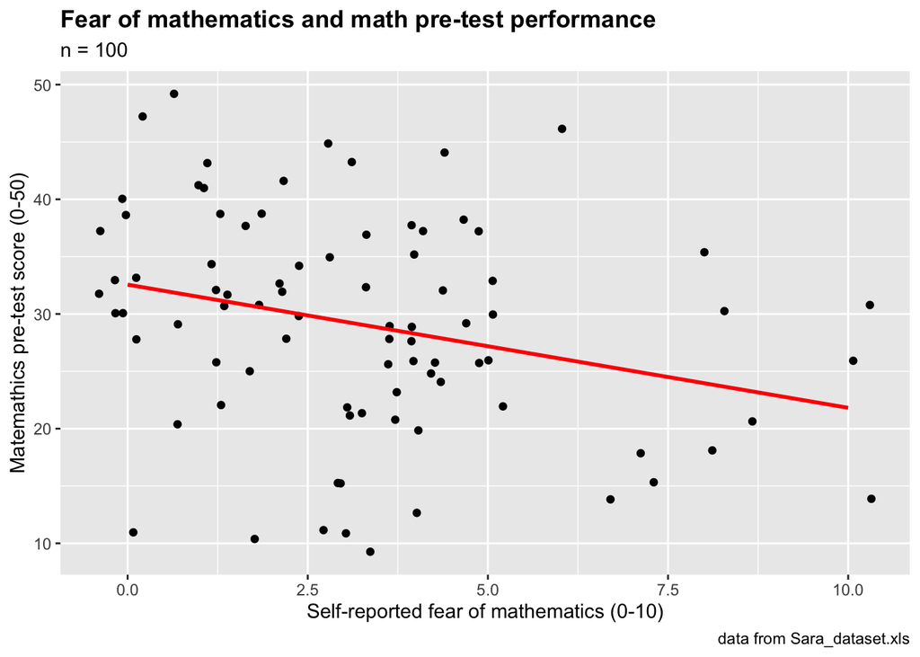

```r
dataset |>
  ggplot(
    aes(
      x = phobia,
      y = mathquiz
    )
  ) +
  geom_jitter() +
  geom_smooth(method = "lm", col = "red", se = FALSE) +
  labs(
    title = "Fear of mathematics and math pre-test performance",
    subtitle = "n = 100",
    x = "Self-reported fear of mathematics (0-10)",
    y = "Matemathics pre-test score (0-50)",
    caption = "data from Sara_dataset.xls"
  ) +
  theme(
    plot.title = element_text(face = "bold"),
  )
```

Self reported fear of mathematics and performance in the mathematics pre-test are negatively correlated ($r =$ -0.28)

## 3.2 Statistics pre-test

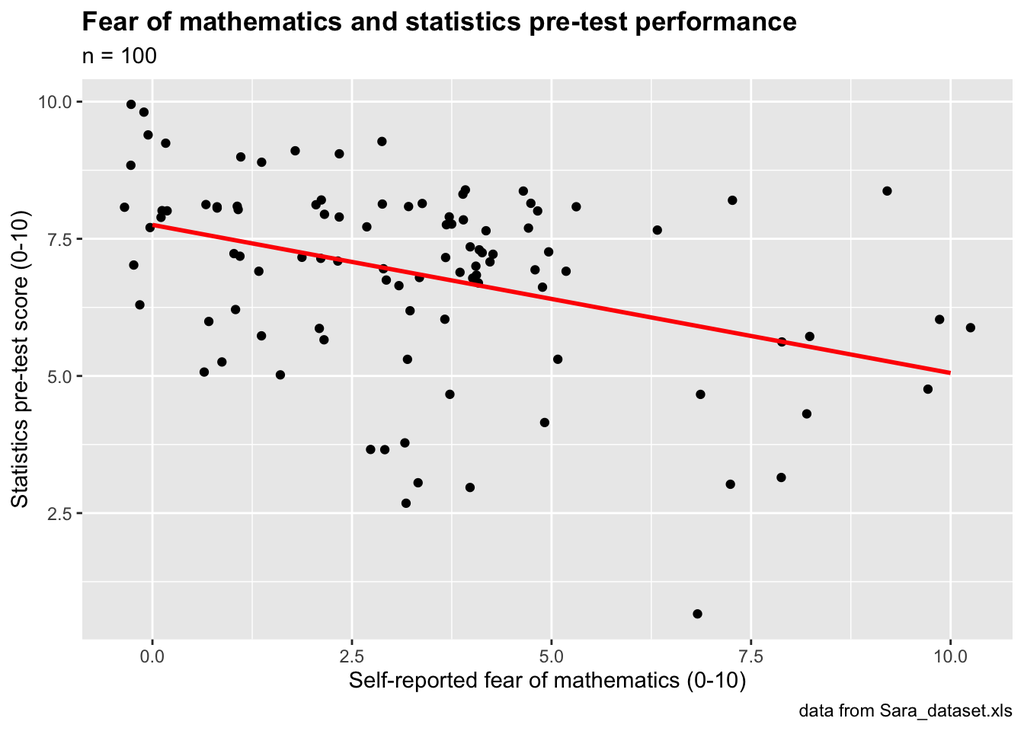

```r
dataset |>
  ggplot(
    aes(
      x = phobia,
      y = statquiz
    )
  ) +
  geom_jitter() +
  geom_smooth(method = "lm", col = "red", se = FALSE) +
  labs(
    title = "Fear of mathematics and statistics pre-test performance",
    subtitle = "n = 100",
    x = "Self-reported fear of mathematics (0-10)",
    y = "Statistics pre-test score (0-10)",
    caption = "data from Sara_dataset.xls"
  ) +
  theme(
    plot.title = element_text(face = "bold"),
  )
```

Self reported fear of mathematics and performance in the statistics pre-test are negatively correlated ($r =$ -0.39)

# 4 Summarizing the results

**Variable**  
Self-reported fear of mathematics (0–10 scale)  
Score on a mathematics pre-test (0-50 scale)  
Score on a statistics pre-test (0-10 scale)

$r$  
1  
-0.28  
-0.39

From the analysis we can conclude that in our sample the performance in a mathematical and a statistical test where negatively correlated with math anxiety (MA).  
This results are consistent with the current research on the topic: a meta-analysis conducted by Zhang et al. (2019) found a robust negative link between math anxiety and math performance.  
Another study also found that countries with higher-than-average student math performance also tend to have lower-than-average student math anxiety (Foley et al., 2017), as seen in Figure 1

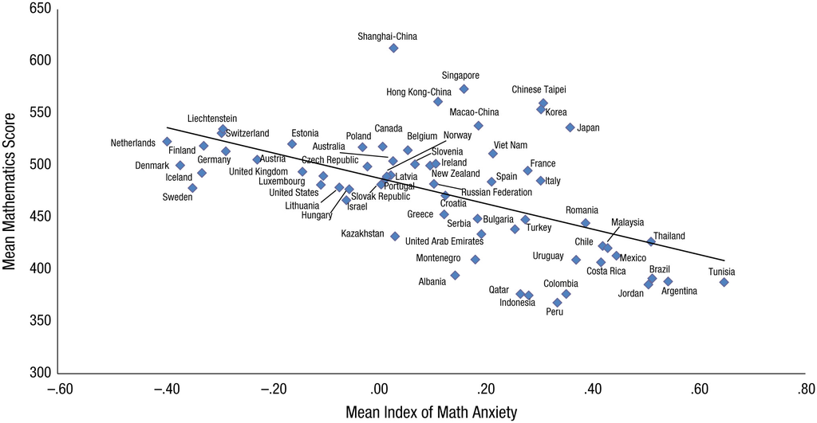

Figure 1: **Fig. 1.** Country-level Program for International Student Assessment (PISA) math score in relation to country-level math anxiety. Adapted from “PISA 2012 Results: Ready to Learn: Students’ Engagement, Drive and Self-Beliefs (Vol. III),” by the Organization for Economic Co-operation and Development, 2013, p. 102. Copyright 2013 by the Organization for Economic Co-operation and Development. Adapted with permission. Foley et al. (2017)

## References

Foley, A. E., Herts, J. B., Borgonovi, F., Guerriero, S., Levine, S. C., & Beilock, S. L. (2017). The math anxiety-performance link: A global phenomenon. *Current Directions in Psychological Science*, *26*(1), 52–58. https://doi.org/10.1177/0963721416672463

Zhang, J., Zhao, N., & Kong, Q. P. (2019). The relationship between math anxiety and math performance: A meta-analytic investigation. *Frontiers in Psychology*, *10*. https://doi.org/10.3389/fpsyg.2019.01613